# Capstone: Memory Group Analysis

## Load libraries

```r
library(dplyr)
```

```r
library(tidyr)
library(ggplot2)
library(stringr)
library(multcomp) #glht
library(readxl)
library(jtools) #summ
library(kableExtra)
library(gridExtra)
```

# Experimental Design

**Industry Partners**

Minnesota Wild & New York Islanders (NHL Teams)

**Research Objective**

Using a behaviorally-informed approach, increase season ticket renewals.

**Behavioral Approach**

*Issue*

The emails sent out to season ticket holders are do not clearly convey the message that they should renew their tickets and the benefits are displayed sloppily in a matrix.

*Solution*

Modify the email format to concisely highlight the main message that season ticket holders should renew their tickets and to better showcase the benefits.

**Control**

Current Minnesota Wild email communications to season ticket holders.

**Treatments**

All treatments have the same concise messaging regarding season ticket renewals. The differences are how we design the benefits matrix.

1. Ranking: Organize the benefits by their rankings according to subjects’ preferences.
2. Categorization: Create buckets relating the benefits (e.g., fan experience, merchandise, etc.) while maintaning the ranking system within each bucket.
3. Reduced List: Display the 5 highest ranked benefits in a matrix. (behavioral economics literature suggest $7\pm2$ choices are optimal for memory recollection).

# Pre-Test

Survey our subject pool on MTurk about their preferences regarding season ticket benefits.

Analysis of pre-test data is used to inform our ranking system for benefits in our treatments.

## Benefit Ranking

```r
#load data
df_pre_dummy = read.csv("Pretest_data.csv", skip = 1)

df_pre = read.csv("Presurvey_nov3.csv", skip = 1)
colnames(df_pre) = colnames(df_pre_dummy)
```

```r
#prep data
#colnames(df_pre)

df_pre_1 = df_pre[-1, c(3, 18, 22:27, 32:42)]

df_pre_2 = df_pre_1[,c(1:3, 9:19)]

df_pre_3 = filter(df_pre_2, Response.Type != "Survey Preview" & Sports.Filter != "0" & MTurk.ID. != "test")

df_pre_fin = df_pre_3 %>%
  pivot_longer(cols = 4:last_col(), names_to = "benefit", values_to = "rank")

df_pre_fin$rank = as.numeric(df_pre_fin$rank) #change class: ch to dbl

df_pre_fin$benefit = gsub("\\.", " ", df_pre_fin$benefit) #replace . with space
```

Multiple ways to categorize/rank the pre-test benefits

*Settled on using top 5 ranking

```r
#Mean ranking
df_pre_fin %>%
  group_by(benefit) %>%
  summarise(mean_count = round(mean(rank), 2)) %>%
  arrange(-mean_count) %>%
  mutate(ranking = 1:nrow(.))
```

```
## # A tibble: 11 x 3
##    benefit                                                    mean_count ranking
##    <chr>                                                           <dbl>   <int>
##  1 Right of first refusal for Xcel Energy Center concerts an~       8.22       1
##  2 X4Ever Wild Rewards                                              7.27       2
##  3 Personal service executive                                       7.15       3
##  4 Hockey lodge discount                                            7.02       4
##  5 Member events                                                    6.49       5
##  6 Interest free payment plans                                      6.39       6
##  7 Easy ticket resale through My Wild Account                       6.07       7
##  8 Additional tickets purchased at a discount with member pr~       5.34       8
##  9 Prepaid parking passes                                           4.24       9
## 10 Same seat guarantee                                              3.95      10
## 11 Playoff access                                                   3.85      11
```

```r
#Median ranking
df_pre_fin %>%
  group_by(benefit) %>%
  summarise(median_count = round(median(rank), 2)) %>%
  arrange(-median_count) %>%
  mutate(ranking = 1:nrow(.))
```

```
## # A tibble: 11 x 3
##    benefit                                                  median_count ranking
##    <chr>                                                           <dbl>   <int>
##  1 Right of first refusal for Xcel Energy Center concerts ~           10       1
##  2 Personal service executive                                          8       2
##  3 X4Ever Wild Rewards                                                 8       3
##  4 Hockey lodge discount                                               7       4
##  5 Interest free payment plans                                         7       5
##  6 Easy ticket resale through My Wild Account                          6       6
##  7 Member events                                                       6       7
##  8 Additional tickets purchased at a discount with member ~            5       8
##  9 Playoff access                                                      3       9
## 10 Prepaid parking passes                                              3      10
## 11 Same seat guarantee                                                 3      11
```

```r
#Top 3 ranking count
#Number of times a benefit is listed as someones top 3
df_pre_fin$top_three = ifelse(df_pre_fin$rank <= 3, 1, 0)

df_pre_fin %>%
  group_by(benefit) %>%
  summarise(top_three_count = sum(top_three)) %>%
  arrange(-top_three_count) %>%
  mutate(ranking = 1:nrow(.))
```

```
## # A tibble: 11 x 3
##    benefit                                               top_three_count ranking
##    <chr>                                                           <dbl>   <int>
##  1 Playoff access                                                     25       1
##  2 Prepaid parking passes                                             23       2
##  3 Same seat guarantee                                                22       3
##  4 Additional tickets purchased at a discount with memb~              10       4
##  5 Easy ticket resale through My Wild Account                          9       5
##  6 Interest free payment plans                                         9       6
##  7 Personal service executive                                          8       7
##  8 X4Ever Wild Rewards                                                 6       8
##  9 Member events                                                       4       9
## 10 Right of first refusal for Xcel Energy Center concer~               4      10
## 11 Hockey lodge discount                                               3      11
```

```r
#Top 5 ranking count
#Number of times a benefit is listed as someones top 5
df_pre_fin$top_five = ifelse(df_pre_fin$rank <= 5, 1, 0)

df_pre_fin %>%
  group_by(benefit) %>%
  summarise(top_five_count = sum(top_five)) %>%
  arrange(-top_five_count) %>%
  mutate(ranking = 1:nrow(.))
```

```
## # A tibble: 11 x 3
##    benefit                                                top_five_count ranking
##    <chr>                                                           <dbl>   <int>
##  1 Same seat guarantee                                                31       1
##  2 Prepaid parking passes                                             30       2
##  3 Playoff access                                                     29       3
##  4 Additional tickets purchased at a discount with membe~             22       4
##  5 Easy ticket resale through My Wild Account                         18       5
##  6 Member events                                                      18       6
##  7 Interest free payment plans                                        16       7
##  8 Hockey lodge discount                                              11       8
##  9 Personal service executive                                         11       9
## 10 X4Ever Wild Rewards                                                10      10
## 11 Right of first refusal for Xcel Energy Center concert~              9      11
```

# Experiment

## Data Prep

```r
#load data
df = read.csv("Memory Project_November 1, 2021_10.46.csv", header = T)
df = read.csv("Memory Project_November 11, 2021_16.19.csv", header = T) #Prelim Data

df = read.csv("Memory Project_November 11, 2021_16.19_buffer_count.csv", header = T)
#colnames(df)
#head(df)
```

```r
#Remove first two rows
df_rem2 = df[-c(1:2),]

#filter based off of std criteria: actual respondents, sports filter, attention check

df_1 = filter(df_rem2, Status == "IP Address", MTurkID != "test", Sports_Filter != "0", attention_check_1 == "Other",
              attention_check_2_1 == "70", attention_check_2_2 == "50")

#ch to dbl
df_1 = transform(df_1,
         Renewal.Liklihood_1 = as.numeric(Renewal.Liklihood_1),
         label = as.factor(label))
```

```r
#change label names using case_when
temp = df_1$label
temp_unique = unique(temp)

df_1$label = case_when(
  temp == temp_unique[1] ~ "Reduced List",
  temp == temp_unique[2] ~ str_to_title(temp_unique[2]),
  temp == temp_unique[3] ~ str_to_title(temp_unique[3]),
  temp == temp_unique[4] ~ str_to_title(temp_unique[4])
)
```

```r
#Add benefit retention memory (%) variable
#Create list of benefits to find correct response proportion in data using grep
#add the two new fake benefits

benefit_list = c("4Ever Wild Rewards", "Discounted Wild Merchandise", "Interest Free Payment Plans", "Hockey Lodge Discount",
                 "Purchase Additional Tickets at a Discounted Rate", "Member Events", "Stadium Tours", "Dedicated Account Manager",
                 "Playoff Access", "Right of First Refusal for Concerts and Events", "Options to Purchase Suites Using flex credit",
                 "Same Seat Guarantee", "Ticket Trade- switch out games you can't attend", "Complimentary Parking",
                 "Gameday Travel Package", "Discounted Concessions", "Early Entry on Game Days",
                 "Exclusive Conferences Calls with Players, Managers, and Front Office Executives",
                 "Free Holiday Ornament", "Access to all streamed NHL Games", "Exclusive Restroom Access", "Autographed Merchandise")

real_benefits = c("4Ever Wild Rewards", "Interest Free Payment Plans", "Hockey Lodge Discount",
                  "Purchase Additional Tickets at a Discounted Rate", "Member Events", "Dedicated Account Manager",
                  "Playoff Access", "Right of First Refusal for Concerts and Events",
                  "Same Seat Guarantee", "Ticket Trade- switch out games you can't attend", "Complimentary Parking")

fake_benefits = benefit_list[!benefit_list %in% real_benefits]

benefit_levels = c(real_benefits, fake_benefits)
```

```r
# if a string contains " Managers" add "Exclusive Conferences Calls with Players, Managers, and Front Office Executives" to list
# Remove "Exclusive Conferences Calls with Players", " Managers", " and Front Office Executives"

do_all_func = function(vec){

  list_temp = strsplit(vec, ",") #extract elements

  list_to_df = function(x){sapply(x, `length<-`, max(lengths(x))) %>% as.matrix() %>% as.data.frame()} #convert to df

  df_list =  list_to_df(list_temp)

  add_func = function(x){

    temp = " Managers" %in% x

    if(temp == T){
      prod = append(x[temp], "Exclusive Conferences Calls with Players, Managers, and Front Office Executives")}
    else{prod = x}
    prod
  }

  add_list = apply(df_list, MARGIN = 2, FUN = add_func) %>% list_to_df()

  #Removal

  drop_vec = c("Exclusive Conferences Calls with Players", " Managers", " and Front Office Executives")

  drop_func = function(x){

    x[x %in% drop_vec == F]
  }

  complete_list = apply(add_list, MARGIN = 2, FUN = drop_func) %>% list_to_df()
  complete_list
}

df_retention = do_all_func(df_1$Initial_Retention)

df_value = do_all_func(df_1$Valued_Retention)
```

```r
#Create data frame with subject on x and words on y, with counts in the cells (1,0)

binary_table = function(df){

  test = function(x){
    xy = table(factor(x, levels = benefit_levels)) %>% data.frame()
    colnames(xy) = c("benefits", "count")

    pivot_wider(xy, names_from = benefits, values_from = count)
  }

  hold = NULL

  for(i in 1:ncol(df)){
    temp = test(df[,i])
    hold = rbind(hold, temp)
  }

  hold
}

mat_retention = binary_table(df_retention)
mat_value = binary_table(df_value)
```

```r
#next step: create proportion of correct responses, proportion of total retention/value
#can cbind label/treatment information post: cbind(df, label = df_1$label)
#set the factor levels so that the first 11 match the first 11 real benefits and the remaining match the fake benefits (done)
#add two false benefits: create a memory score --> +1 for correct answer, -1 for incorrect answer

#false recall: # times F vs # T times
#******FIX INDEXING****** if needed

prep_rep_func = function(mat_retention){

n_attempts = apply(mat_retention, 1, sum) #sum across rows w binary entries to get total attempts

mat_retention$T_num = apply(mat_retention[,1:11], 1, sum) #sum T across rows

mat_retention$F_num = apply(mat_retention[,12:22], 1, sum) #sum F across rows

mat_retention$memory_score = mat_retention$T_num - mat_retention$F_num #memory score

mat_retention_fin = cbind(label = df_1$label, n_attempts, mat_retention)

#add payment col: payment is +$0.05 for correct & -$0.05 for false (floor at zero)

mat_retention_fin$user_payment = mat_retention_fin$memory_score * 0.05

mat_retention_fin$user_payment = ifelse(mat_retention_fin$user_payment < 0, 0, mat_retention_fin$user_payment)

#cbind renewal likelihood

mat_retention_fin_pre = cbind(mat_retention_fin, Renewal.Liklihood_1 = df_1$Renewal.Liklihood_1, Gender = df_1$Gender)
mat_retention_fin_pre
}

mat_retention_fin_pre = prep_rep_func(mat_retention)

mat_value_fin_pre = prep_rep_func(mat_value)
```

```r
#Timing var
#last click vs page submit

num_round = function(x){round(as.numeric(x), 2)}

#make timing numeric
df_1 = transform(df_1,
          Control_time_First.Click = num_round(Control_time_First.Click),
          Control_time_Last.Click = num_round(Control_time_Last.Click),
          Control_time_Page.Submit = num_round(Control_time_Page.Submit),

          Reduced_time_First.Click = num_round(Reduced_time_First.Click),
          Reduced_time_Last.Click = num_round(Reduced_time_Last.Click),
          Reduced_time_Page.Submit = num_round(Reduced_time_Page.Submit),

          Ranking_time_First.Click = num_round(Ranking_time_First.Click),
          Ranking_time_Last.Click = num_round(Ranking_time_Last.Click),
          Ranking_time_Page.Submit = num_round(Ranking_time_Page.Submit),

          Categorization_time_First.Click = num_round(Categorization_time_First.Click),
          Categorization_time_Last.Click = num_round(Categorization_time_Last.Click),
          Categorization_time_Page.Submit = num_round(Categorization_time_Page.Submit),

          Buffer_time_First.Click = num_round(Buffer_time_First.Click),
          Buffer_time_Last.Click = num_round(Buffer_time_Last.Click),
          Buffer_time_Page.Submit = num_round(Buffer_time_Page.Submit),

          Buffer_list_time_First.Click = num_round(Buffer_list_time_First.Click),
          Buffer_list_time_Last.Click = num_round(Buffer_list_time_Last.Click),
          Buffer_list_time_Page.Submit = num_round(Buffer_list_time_Page.Submit))

#Based on page submit
xx = paste(df_1$Control_time_Page.Submit, df_1$Reduced_time_Page.Submit, df_1$Ranking_time_Page.Submit,
           df_1$Categorization_time_Page.Submit) %>%
  data.frame()

sub_NA = function(df){gsub("NA", "", df)}

time_clean_func = function(mat_retention_fin_pre){

mat_retention_fin_pre$page_time = apply(xx, 1, sub_NA) %>% as.numeric()

#Remove observations over 2 minutes (120 seconds) and under 3 seconds & add age variable

mat_retention_fin_1 = mat_retention_fin_pre %>% mutate(age = as.numeric(df_1$Age), buffer_count = df_1$Count, .before = n_attempts) %>%
  filter(page_time >=3, page_time <= 120)

mat_retention_fin_1
}

mat_retention_fin_1 = time_clean_func(mat_retention_fin_pre)

mat_value_fin_1 = time_clean_func(mat_value_fin_pre)
```

```r
#Create Age Buckets
temp = mat_retention_fin_1$age
age_bucket = ifelse(temp >= 18 & temp <= 34, "18-34",
                    ifelse(temp >= 35 & temp <= 50, "35-50", "Older than 50"))

mat_retention_fin_1 = mat_retention_fin_1 %>% mutate(age_bucket = as.factor(age_bucket), .after = age)
```

```r
#proportion of correct responses over total buffer words
#mutate proportion into mat_retention_fin_1
n_buffer = 15 #number of buffer words
mat_retention_fin_1$prop_buffer = mat_retention_fin_1$buffer_count/n_buffer

#Group by buffer memory (median split)
temp = mat_retention_fin_1$prop_buffer
cutoff = median(temp)

mat_retention_fin_1 = mutate(mat_retention_fin_1, buffer_group = ifelse(temp >= cutoff, 1, 0) %>% as.factor(), .after = buffer_count)
```

## EDA

#### Condition size n

```r
mat_retention_fin_1 %>%
  group_by(label) %>%
  summarise(n_subjects = n())
```

```
## # A tibble: 4 x 2
##   label          n_subjects
##   <chr>               <int>
## 1 Categorization         97
## 2 Control                91
## 3 Ranking                92
## 4 Reduced List           94
```

### Memory

Need to take proportion approach to account for limited choice set for the ‘reduced list’ treatment

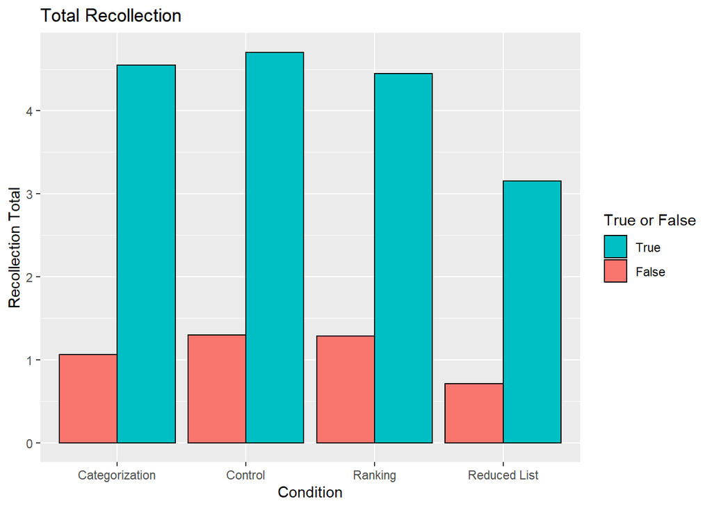

```r
#False/True: Total, Proportion

#new x: difference in proportions to control for diff in benefit options and n_attempts

mat_retention_fin_1 = mat_retention_fin_1 %>%
  mutate(prop_T = round(T_num/n_attempts, 3),
         prop_F = round(F_num/n_attempts, 3),
         prop_diff = prop_T-prop_F)

mat_retention_fin_1 %>%
  group_by(label) %>%
  summarise(True = mean(T_num),
            False = mean(F_num)) %>%
  pivot_longer(cols = True:False,
               names_to = "T_or_F",
               values_to = "Total") %>%
  ggplot(aes(x = label, y = Total, fill = T_or_F)) +
  geom_col(col = "black", position = "dodge") +
  labs(title = "Total Recollection", x = "Condition", y = "Recollection Total", fill = "True or False") +
  guides(fill = guide_legend(reverse=TRUE))
```

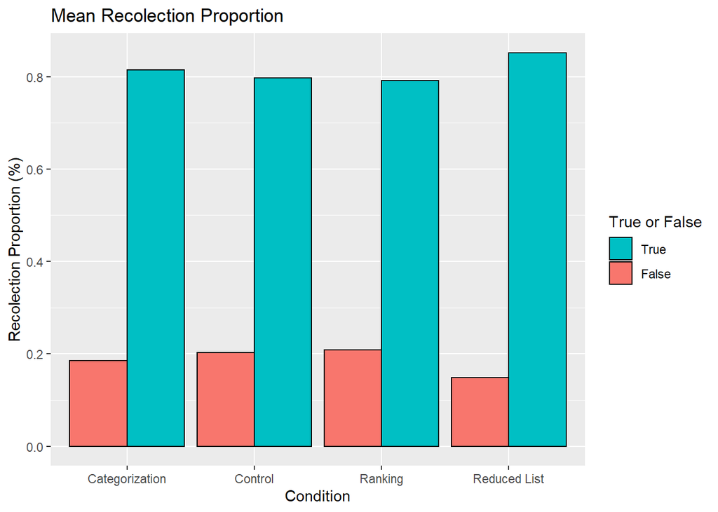

```r
mat_retention_fin_1 %>%
  group_by(label) %>%
  summarise(True = mean(prop_T),
            False = mean(prop_F)) %>%
  pivot_longer(cols = True:False,
               names_to = "T_or_F",
               values_to = "Total") %>%
  ggplot(aes(x = label, y = Total, fill = T_or_F)) +
  geom_col(position = "dodge", col = "black") +
  labs(title = "Mean Recolection Proportion", x = "Condition", y = "Recolection Proportion (%)", fill = "True or False")  +
  guides(fill = guide_legend(reverse=TRUE))
```

True recollection represents correct benefit recall and false recollection represents incorrect benefit recall.

Participants in the reduced list had the greatest true recollection and the least false recollections (proportionally). Note that this finding is not statistically significant.

Subjects are grouped whether they are above or below the median memory performance on the buffer activity

Control for subjects with inherently good or bad memorization skills

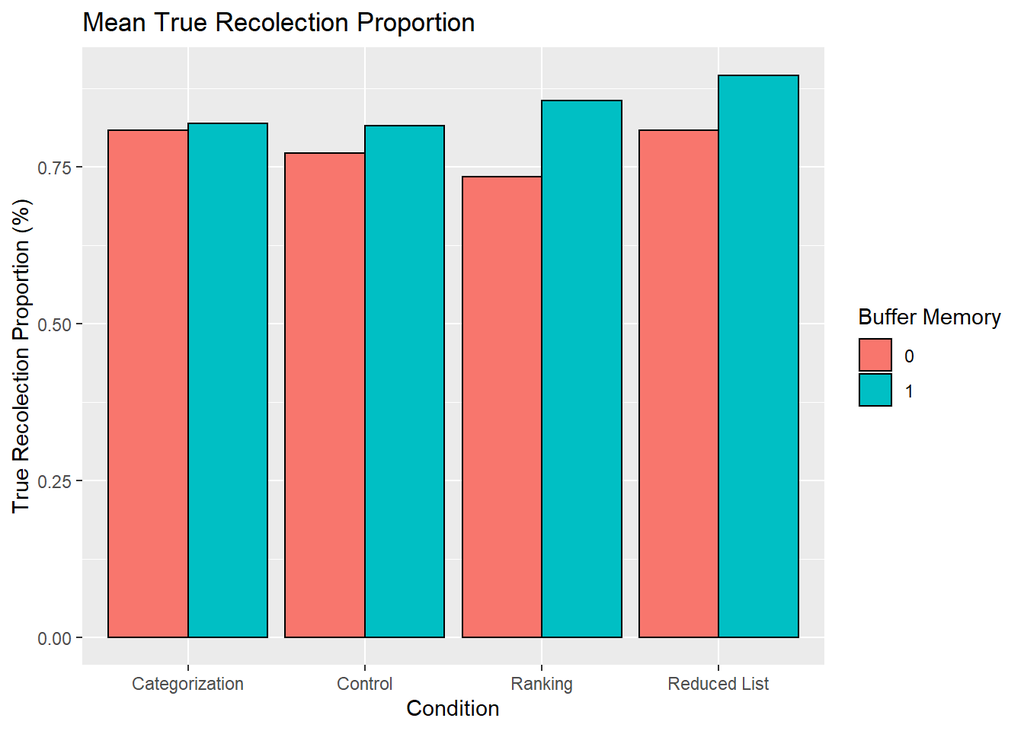

```r
#color by buffer median and group by condition
mat_retention_fin_1 %>%
  group_by(label, buffer_group) %>%
  summarise(mean_prop_T = mean(prop_T)) %>%
  ggplot(aes(x = label, y = mean_prop_T, fill = buffer_group)) +
  geom_col(col = "black", position = "dodge") +
  labs(title = "Mean True Recolection Proportion", x = "Condition", y = "True Recolection Proportion (%)", fill = "Buffer Memory")
```

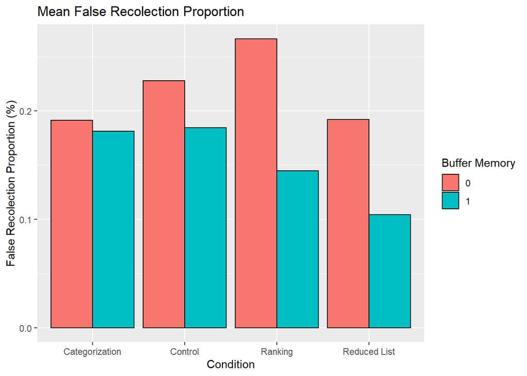

```r
mat_retention_fin_1 %>%
  group_by(label, buffer_group) %>%
  summarise(mean_prop_F = mean(prop_F)) %>%
  ggplot(aes(x = label, y = mean_prop_F, fill = buffer_group)) +
  geom_col(col = "black", position = "dodge") +
  labs(title = "Mean False Recolection Proportion", x = "Condition", y = "False Recolection Proportion (%)", fill = "Buffer Memory")
```

Individuals performing above the median in the buffer test appear to have systemically higher true recollection than individuals performing above the median.

Individuals performing below the median in the buffer test appear to have systemically higher false recollection than individuals performing above the median.

Note that both of these observations are separated by a narrow margin for subjects in the categorization condition.

#### Timing

Analysis of the amount of time subjects are spending looking at the emails.

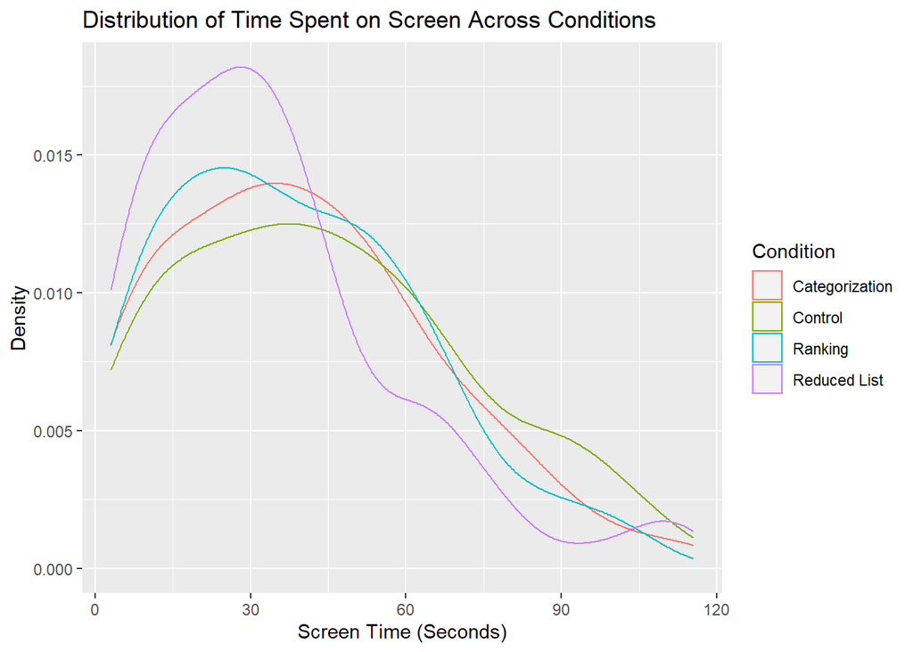

```r
#bar chart of mean timing colored by treatment
ggplot(mat_retention_fin_1, aes(x = page_time, col = label)) +
  geom_density() +
  labs(title = "Distribution of Time Spent on Screen Across Conditions", x = "Screen Time (Seconds)", col = "Condition", y = "Density")
```

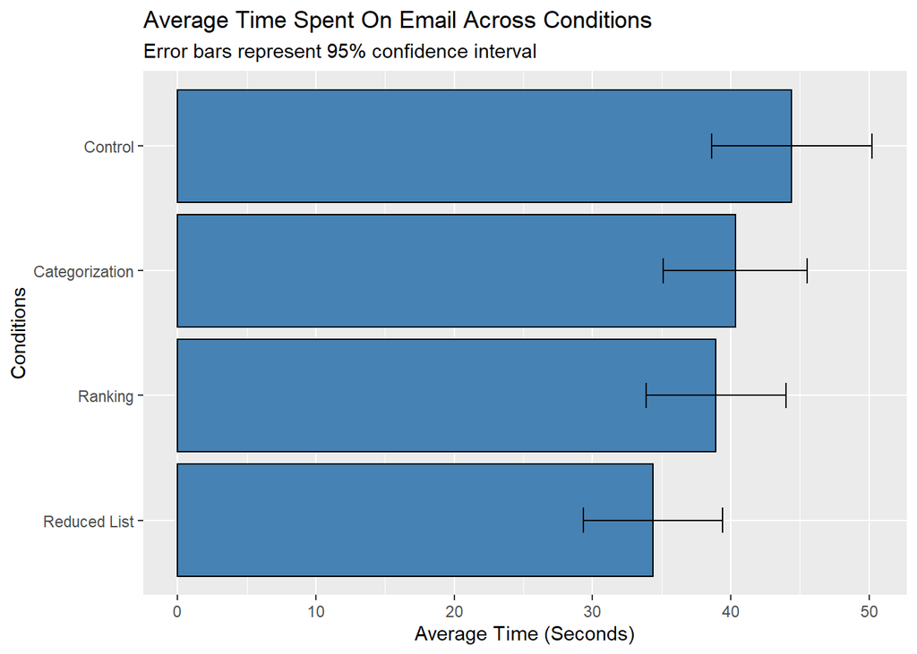

```r
position = mat_retention_fin_1 %>%
  group_by(label) %>%
  summarise(mean_time = mean(page_time)) %>%
  arrange(mean_time) %>%
  pull(1)

mat_retention_fin_1 %>%
  group_by(label) %>%
  summarise(mean_time = mean(page_time),
            sd = sd(page_time, na.rm = T),
            se = sd / sqrt(n()),
            alpha = 0.05,
            t = qt((1-alpha)/2 + .5, n()-1),   # tend to 1.96 if sample size is big enough
            CI = t*se) %>%
  ggplot(aes(x = label, y = mean_time)) +
  geom_col(fill = "steelblue", col = "black") +
  geom_errorbar(aes(ymin = mean_time - CI, ymax= mean_time + CI), width = .2) +
  scale_x_discrete(limits = position) +
  coord_flip() +
  labs(title = "Average Time Spent On Email Across Conditions", x = "Conditions", y = "Average Time (Seconds)",
       subtitle = "Error bars represent 95% confidence interval")
```

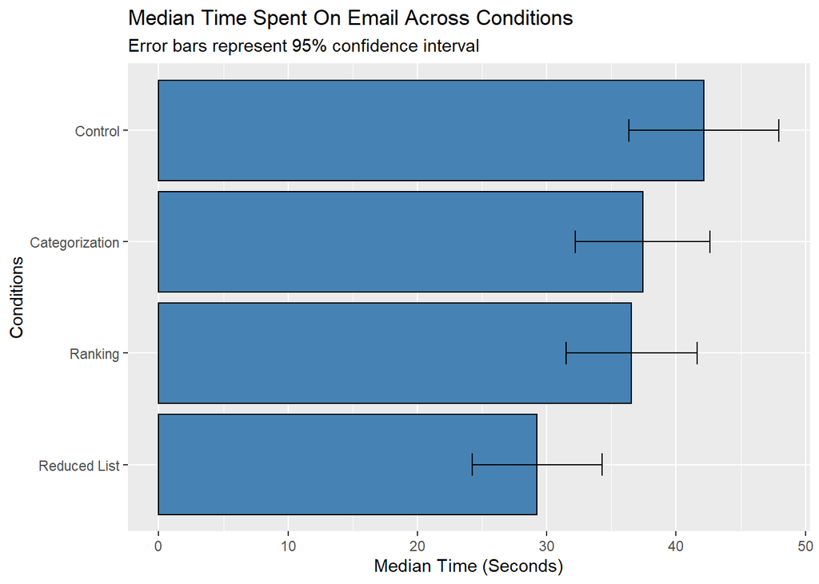

```r
mat_retention_fin_1 %>%
  group_by(label) %>%
  summarise(median_time = median(page_time),
            sd =  sd(page_time, na.rm = T),
            se = sd / sqrt(n()),
            alpha = 0.05,
            t = qt((1-alpha)/2 + .5, n()-1), # tend to 1.96 if sample size is big enough) %>%
            CI = t*se) %>%
  ggplot(aes(x = label, y = median_time)) +
  geom_col(fill = "steelblue", col = "black") +
  geom_errorbar(aes(ymin = median_time - CI, ymax= median_time + CI), width = .2) +
  scale_x_discrete(limits = position) +
  coord_flip() +
  labs(title = "Median Time Spent On Email Across Conditions", x = "Conditions", y = "Median Time (Seconds)",
       subtitle = "Error bars represent 95% confidence interval")
```

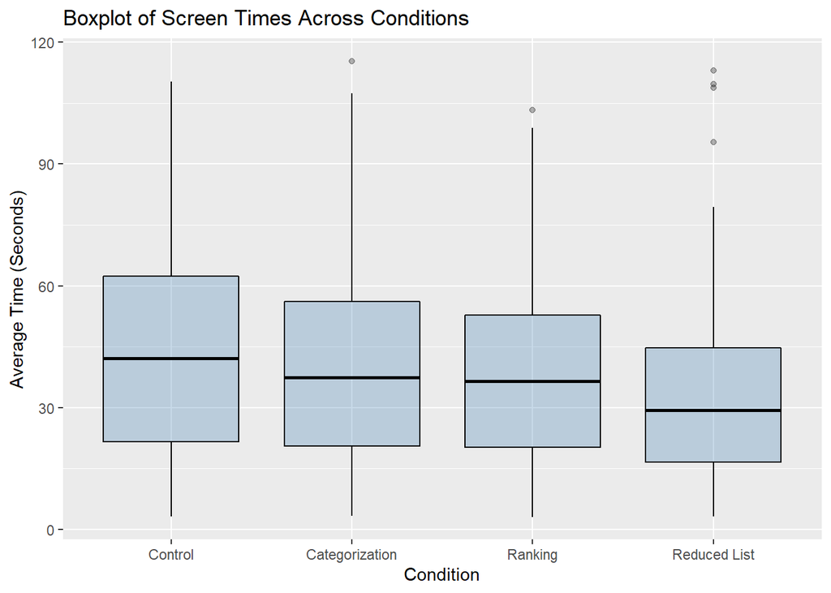

```r
position = mat_retention_fin_1 %>%
  group_by(label) %>%
  summarise(median_time = median(page_time)) %>%
  arrange(-median_time) %>%
  pull(1)

ggplot(mat_retention_fin_1) +
  geom_boxplot(aes(x = label, y = page_time), col = "black", fill = "steelblue", alpha = 0.3) +
  scale_x_discrete(limits = position) +
  labs(title = "Boxplot of Screen Times Across Conditions", x = "Condition", y = "Average Time (Seconds)")
```

Screen time is not significantly different among the treatments and control but the reduced list email condition has the lowest average time spent on screen. This does not come as a surprise considering it contains 6 fewer benefits than the other conditions.

Also the control appears to have the highest screen time which may be attributed to its lack of clarity in displaying the benefits and its bulky text requesting season ticket renewals.

#### Memory Score

Memory score is defined as the difference between correct and incorrect benefit recollection.

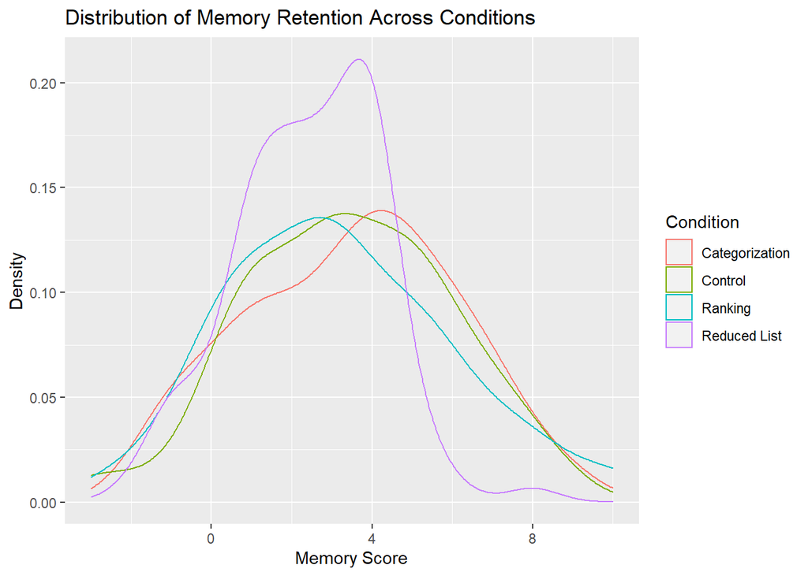

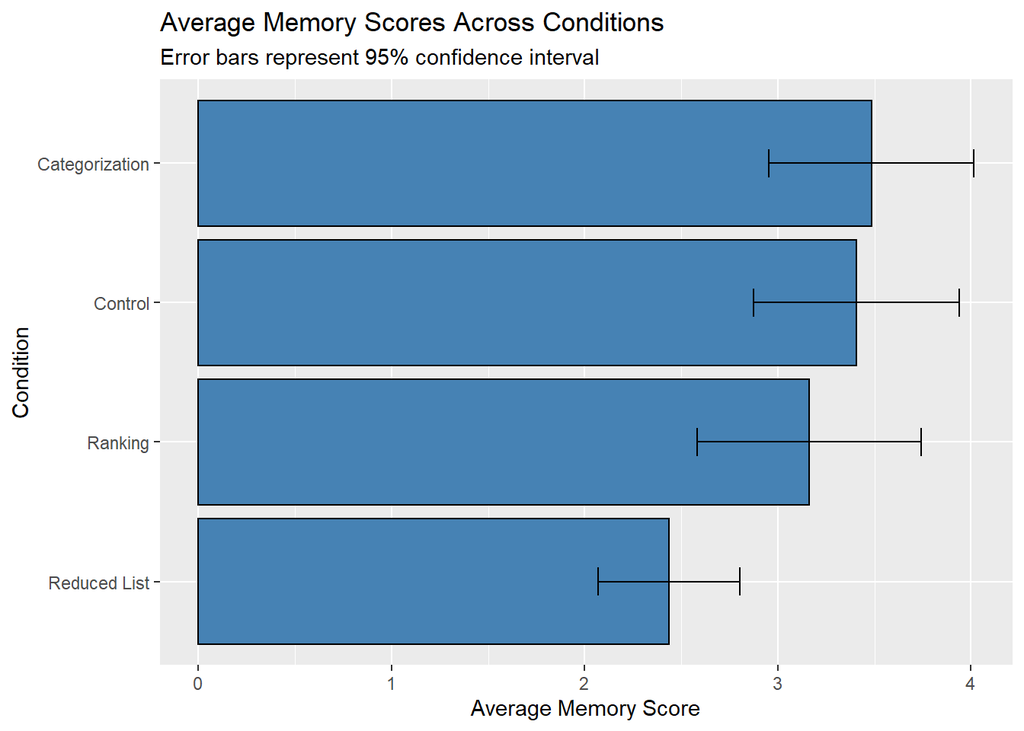

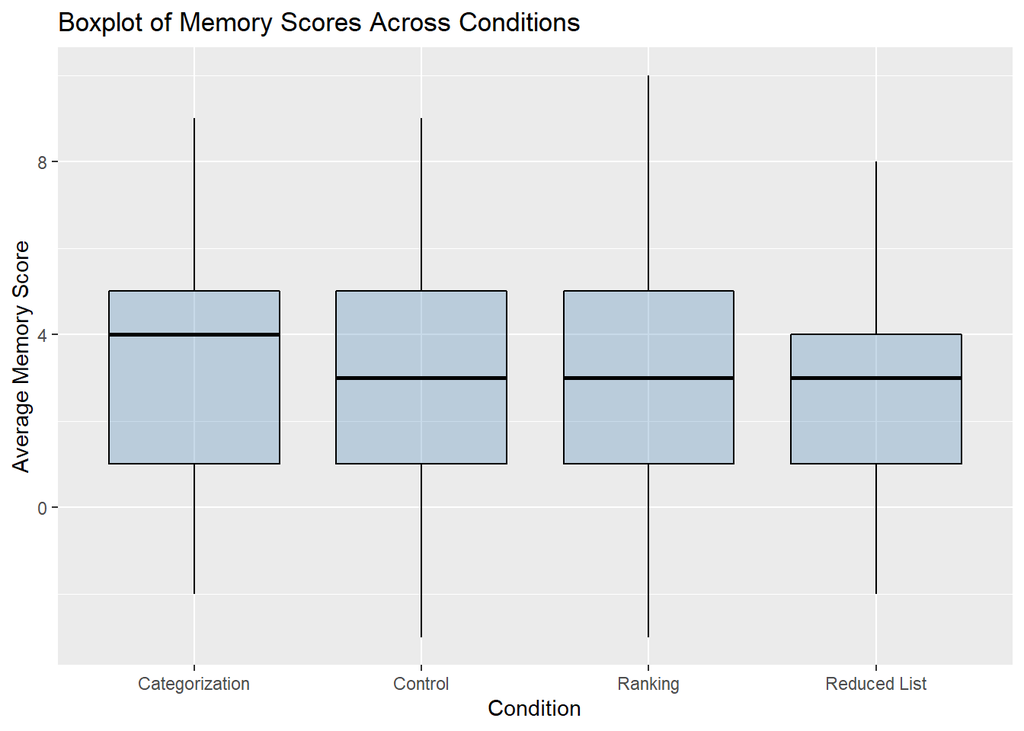

```r
#plot in func as list

ms_plot_func = function(mat_retention_fin_1){

p1 = ggplot(mat_retention_fin_1, aes(x = memory_score, col = label)) +
  geom_density() +
  labs(title = "Distribution of Memory Retention Across Conditions", x = "Memory Score", col = "Condition", y = "Density")

#determine factor positioning
positions = mat_retention_fin_1 %>%
  group_by(label) %>%
  summarise(mean_memory = mean(memory_score)) %>%
  arrange(-mean_memory) %>%
  pull(1)

#bar chart of memory score grouped by treatment
p2 = mat_retention_fin_1 %>%
  group_by(label) %>%
  summarise(mean_memory = mean(memory_score),
            sd = sd(memory_score, na.rm = T),
            se = sd / sqrt(n()),
            alpha = 0.05,
            t = qt((1-alpha)/2 + .5, n()-1), # tend to 1.96 if sample size is big enough) %>%
            CI = t*se) %>%
  ggplot(aes(x = label, y = mean_memory)) +
  geom_col(fill = "steelblue", col = "black") +
  geom_errorbar(aes(ymin = mean_memory - CI, ymax= mean_memory + CI), width = .2) +
  scale_x_discrete(limits = positions[length(positions):1]) + #reverse string
  coord_flip() +
  labs(title = "Average Memory Scores Across Conditions", x = "Condition", y = "Average Memory Score",
       subtitle = "Error bars represent 95% confidence interval")

#boxplot of MS by condition
p3 = ggplot(mat_retention_fin_1) +
  geom_boxplot(aes(x = label, y = memory_score), col = "black", fill = "steelblue", alpha = 0.3) +
  scale_x_discrete(limits = positions) +
  labs(title = "Boxplot of Memory Scores Across Conditions", x = "Condition", y = "Average Memory Score")

list(p1,p2,p3)
}

ms_plot_func(mat_retention_fin_1)
```

Across groups there is no significant difference in memory scores (not including the reduced list condition).

Note that the reduced list condition has a smaller memory score because it presents subjects with fewer benefits. This reduced choice set sets a smaller cap of their memory score relative to the other conditions.

#### Renewal Likelihood

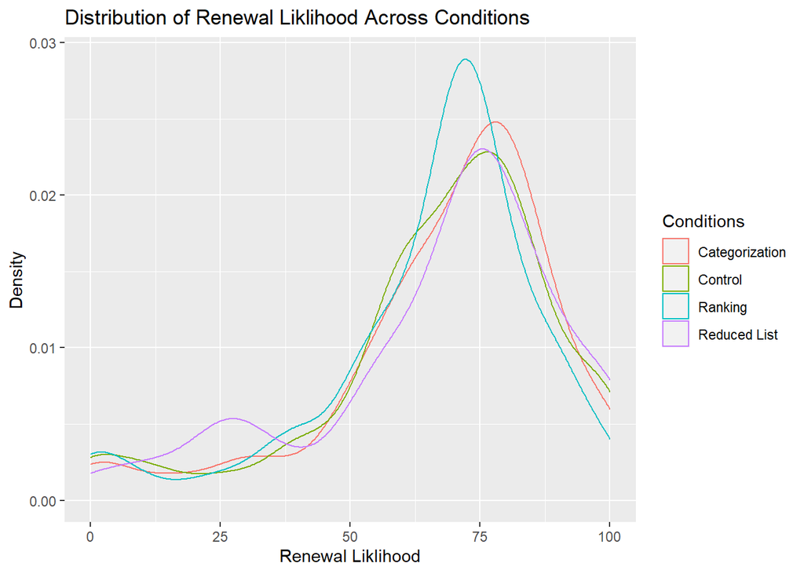

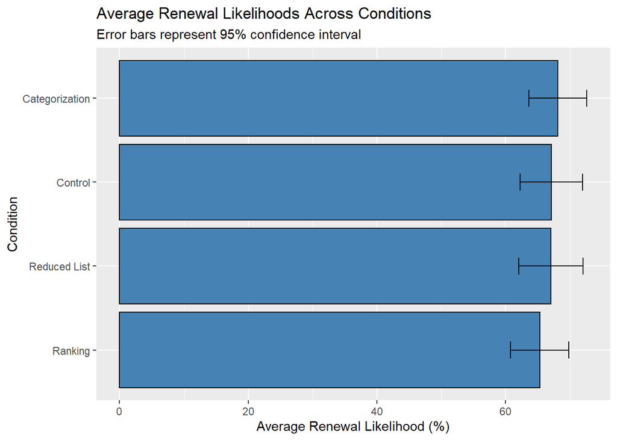

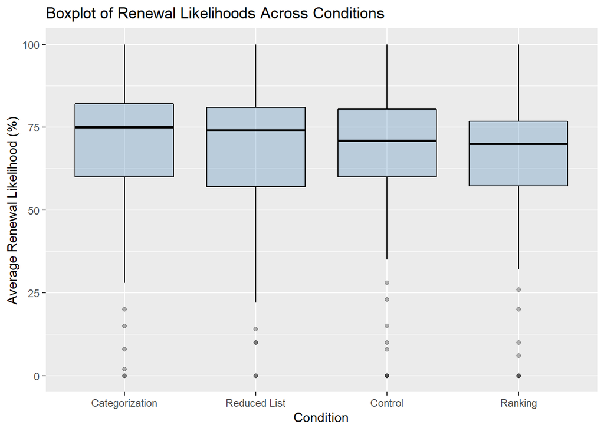

```r
#RL density plot colored by condition
rl_plot_func = function(mat_retention_fin_1){

p1 = ggplot(mat_retention_fin_1, aes(x = (Renewal.Liklihood_1), col = label)) +
  geom_density() +
  labs(title = "Distribution of Renewal Liklihood Across Conditions", x = "Renewal Liklihood", y = "Density", col = "Conditions")

#determine factor positioning
positions = mat_retention_fin_1 %>%
  group_by(label) %>%
  summarise(mean_renewal = mean(Renewal.Liklihood_1)) %>%
  arrange(-mean_renewal) %>%
  pull(1)

#bar chart of renewal likelihood grouped by treatment
p2 = mat_retention_fin_1 %>%
  group_by(label) %>%
  summarise(mean_renewal = mean(Renewal.Liklihood_1),
            sd = sd(Renewal.Liklihood_1, na.rm = T),
            se = sd / sqrt(n()),
            alpha = 0.05,
            t = qt((1-alpha)/2 + .5, n()-1), # tend to 1.96 if sample size is big enough) %>%
            CI = t*se) %>%
  ggplot(aes(x = label, y = mean_renewal)) +
  geom_col(fill = "steelblue", col = "black") +
  geom_errorbar(aes(ymin = mean_renewal - CI, ymax = mean_renewal + CI), width = .2) +
  scale_x_discrete(limits = positions[length(positions):1]) + #reverse string
  coord_flip() +
  labs(title = "Average Renewal Likelihoods Across Conditions", x = "Condition", y = "Average Renewal Likelihood (%)",
       subtitle = "Error bars represent 95% confidence interval")

#boxplot of RL by condition

positions = mat_retention_fin_1 %>%
  group_by(label) %>%
  summarise(median_renewal = median(Renewal.Liklihood_1)) %>%
  arrange(-median_renewal) %>%
  pull(1)

p3 = ggplot(mat_retention_fin_1) +
  geom_boxplot(aes(x = label, y = Renewal.Liklihood_1), col = "black", fill = "steelblue", alpha = 0.3) +
  scale_x_discrete(limits = positions) +
  labs(title = "Boxplot of Renewal Likelihoods Across Conditions", x = "Condition", y = "Average Renewal Likelihood (%)")

list(p1,p2,p3)

}

rl_plot_func(mat_retention_fin_1)
```

There is no statistically significant difference in renewal likelihoods across the conditions.

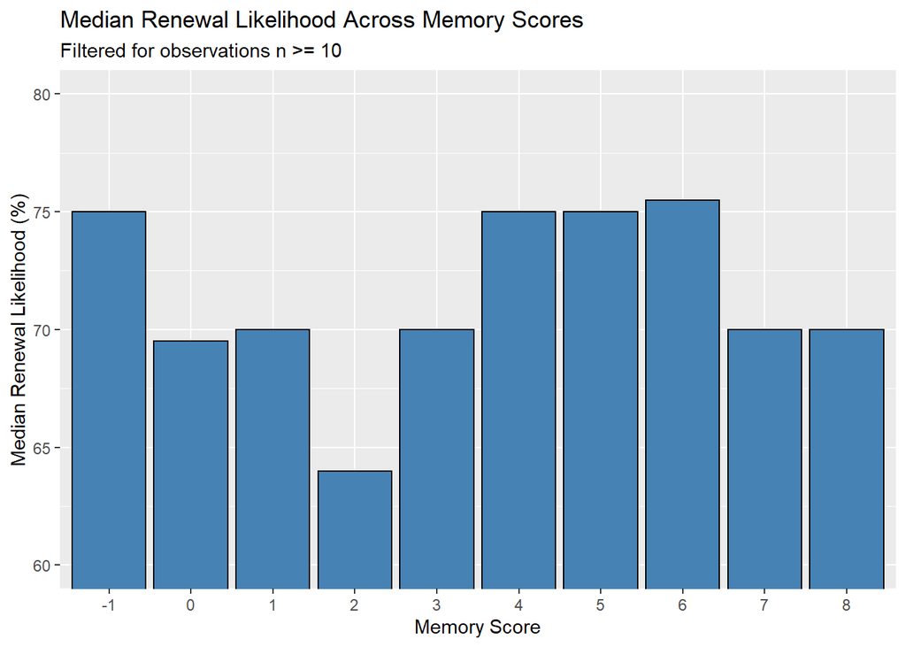

```r
#memory vs renewal likelihood
#trying to visualize connection between memory score and renewal likelihood

mat_retention_fin_1 %>%
  group_by(h = as.factor(memory_score)) %>%
  summarise(med_renewal = median(Renewal.Liklihood_1), count = n()) %>%
  filter(., count >= 10) %>% #filter out small sample size
  ggplot(aes(x = h, y = med_renewal)) +
  geom_col(col = "black", fill = "steelblue") +
  coord_cartesian(ylim = c(60, 80)) +
  labs(title = "Median Renewal Likelihood Across Memory Scores", x = "Memory Score", y = "Median Renewal Likelihood (%)",
       subtitle = "Filtered for observations n >= 10")
```

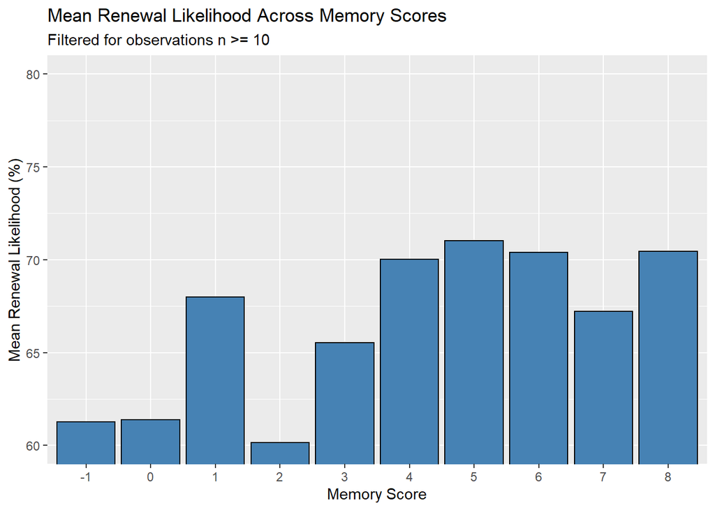

```r
mat_retention_fin_1 %>%
  group_by(h = as.factor(memory_score)) %>%
  summarise(mean_renewal = mean(Renewal.Liklihood_1), count = n()) %>%
  filter(., count >= 10) %>% #filter out small sample size
  ggplot(aes(x = h, y = mean_renewal)) +
  geom_col(col = "black", fill = "steelblue") +
  coord_cartesian(ylim = c(60, 80)) + #zoom in
  labs(title = "Mean Renewal Likelihood Across Memory Scores", x = "Memory Score", y = "Mean Renewal Likelihood (%)",
       subtitle = "Filtered for observations n >= 10")
```

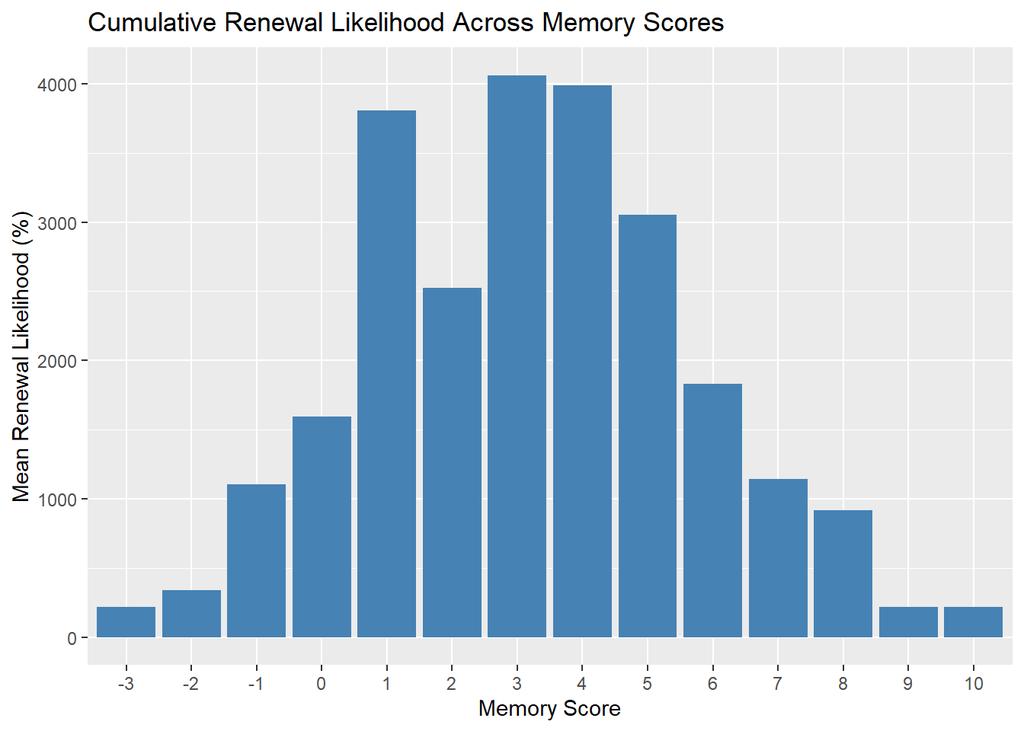

```r
ggplot(mat_retention_fin_1, aes(x = as.factor(memory_score), y = Renewal.Liklihood_1)) +
  geom_col(fill = "steelblue") +
  labs(title = "Cumulative Renewal Likelihood Across Memory Scores", x = "Memory Score", y = "Mean Renewal Likelihood (%)")
```

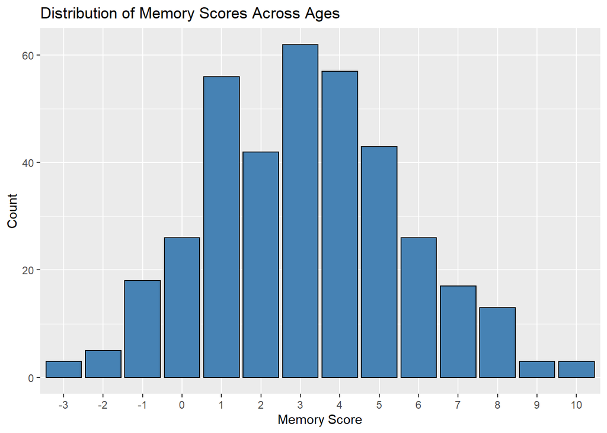

```r
ggplot(mat_retention_fin_1, aes(x = as.factor(memory_score))) +
         geom_bar(fill = "steelblue", col = "black") +
  labs(title = "Distribution of Memory Scores Across Ages", y = "Count", x = "Memory Score")
```

There may be a positive relationship between memory scores and renewal likelihoods that should be explored in the modeling section via regression analysis.

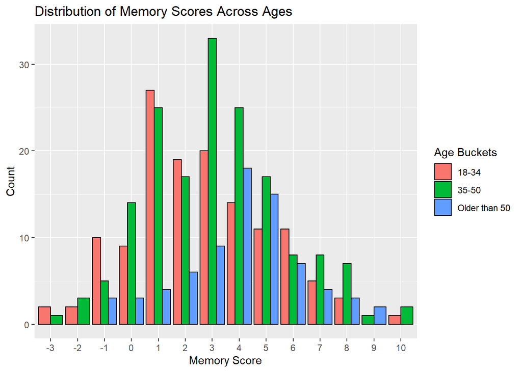

```r
#Age Buckets
ggplot(mat_retention_fin_1, aes(x = as.factor(memory_score))) +
         geom_bar(aes(fill = age_bucket), col = "black", position = "dodge") +
  labs(title = "Distribution of Memory Scores Across Ages", y = "Count", x = "Memory Score", fill = "Age Buckets")
```

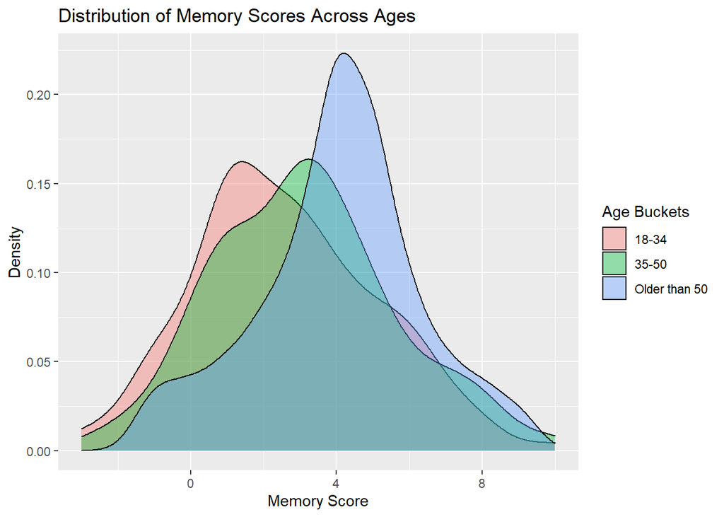

```r
ggplot(mat_retention_fin_1, aes(x = memory_score)) +
         geom_density(aes(fill = age_bucket), alpha = 0.4) +
  labs(title = "Distribution of Memory Scores Across Ages", y = "Density", x = "Memory Score", fill = "Age Buckets")
```

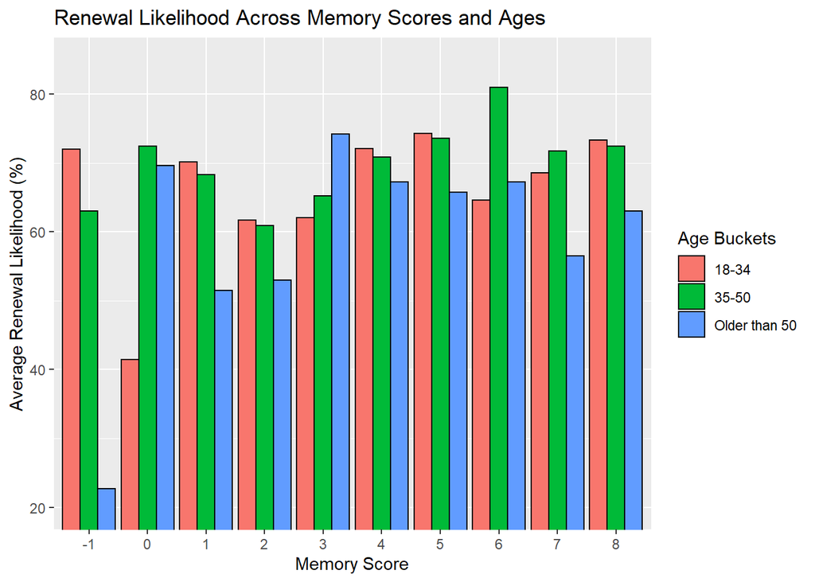

```r
n_scores = mat_retention_fin_1 %>%
  group_by(memory_score) %>%
  summarise(count = n()) %>%
  filter(., count >= 10) %>%
  pull(1)

mat_retention_fin_1 %>%
  filter(., memory_score %in% n_scores) %>% #"WHERE col IN vec" like SQL, ~ iterated or statement
  group_by(memory_score, age_bucket) %>%
  summarise(mean_renewal = mean(Renewal.Liklihood_1),
            count = n()) %>%
  ggplot(aes(x = as.factor(memory_score), y = mean_renewal, fill = age_bucket)) +
  geom_col(col = "black", position = "dodge") +
  coord_cartesian(ylim = c(20, 85)) + #zoom in
  labs(title = "Renewal Likelihood Across Memory Scores and Ages", y = "Average Renewal Likelihood (%)",
       x = "Memory Score", fill = "Age Buckets")
```

Older subjects (>50) appear to have a better memory score across all the conditions compared to other age groups.

### Value

Analysis of benefits that subjects remembered and value.

Note: Our analysis, findings, and presentation mostly concerned benefit memory retention and its impact on season ticket renewals rather than valued benefits.

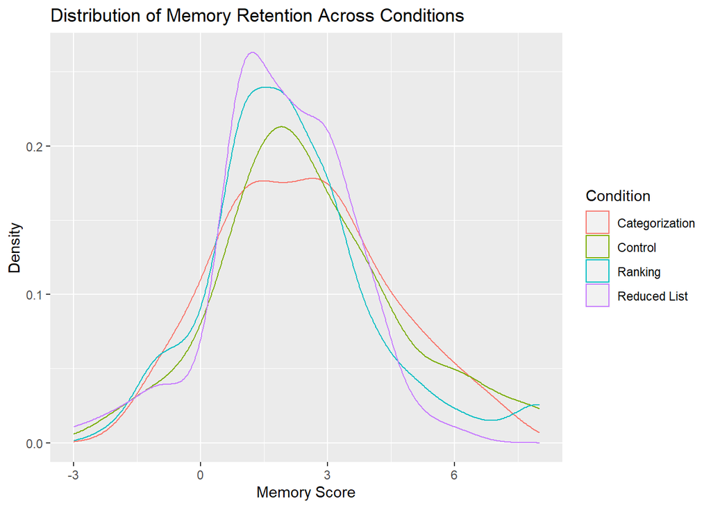

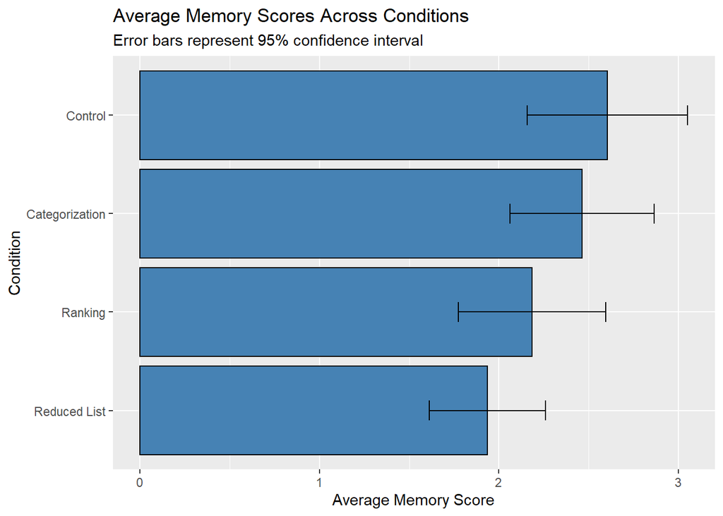

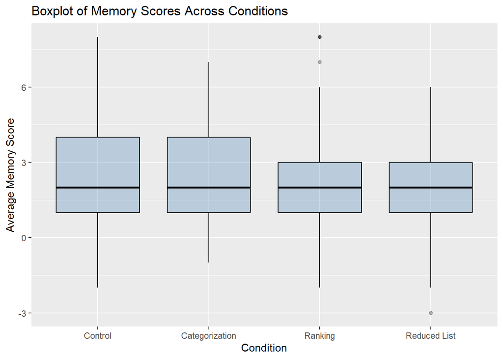

```r
#memory score
ms_plot_func(mat_value_fin_1)
```

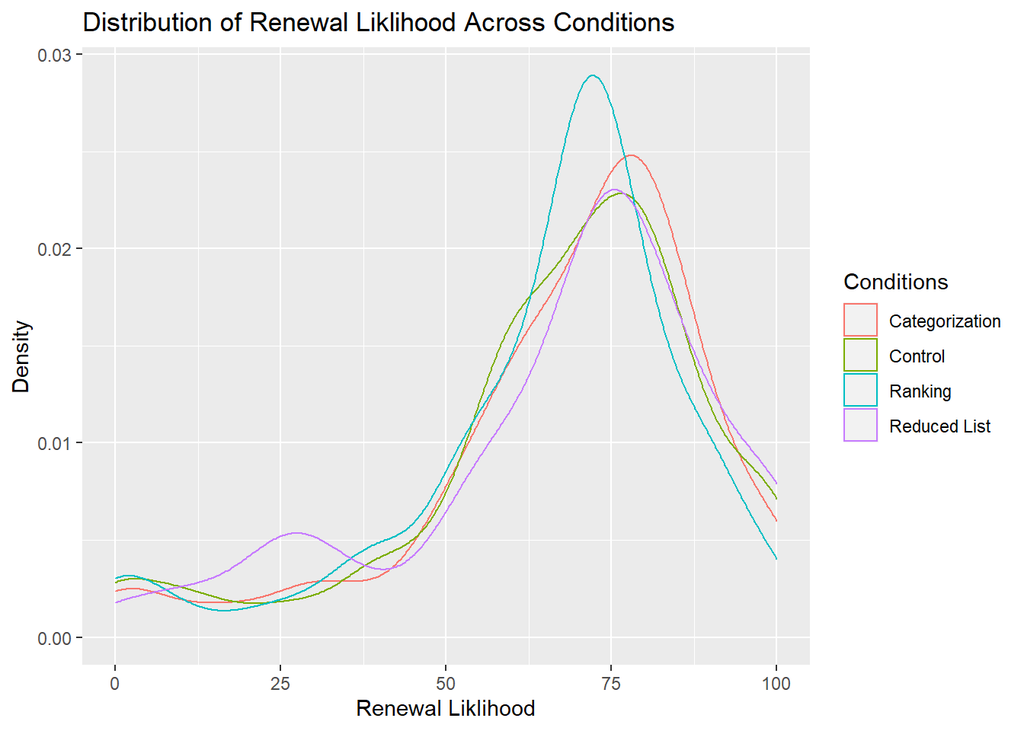

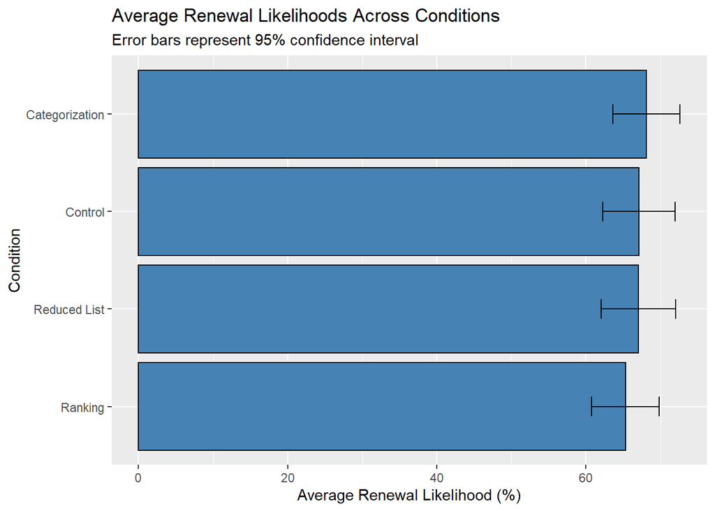

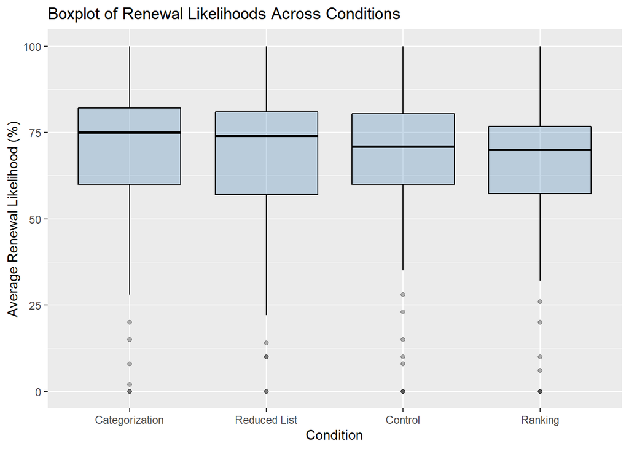

```r
#renewal likelihood

rl_plot_func(mat_value_fin_1)
```